# ADL - Bathing or showering

# 1 Description of DataSchema variable

- Short name: `adl_bathing`
- Variable label: `ADL-Difficulties for bathing or showering`
- Domain: `Health status and functional limitations`
- Value type: `categorical`
- Category coding:

| **Code** | **Category Label** |
| --- | --- |
| 0 | yes |
| 1 | no |

- Category missings:

| **Code** | **Category Label** |
| --- | --- |
| 991 | CAPI/interviewer error |
| 992 | Impute |
| 993 | Disable to measure |
| 994 | Not attempt/not done |
| 995 | Does not answer |
| 996 | Not applicable |
| 997 | Refuse |
| 998 | Do not know |
| 999 | Missing |

# 2 Data process

## 2.1 England

### 2.1.1 Wave 1

#### 2.1.1.1 Study-specific variable description

- Name: `headlba`
- Label: `ADL: difficulty bathing or showering`
- Categories:
  - `0 = Not mentioned`
  - `1 = Mentioned`
- Missings
  - `-9 = Refusal`
  - `-8 = Don't know`
  - `-1 = Not applicable`
- Description:

| Sample size | Missing values |
| --- | --- |
| 12099 | 0 |

Category

|  | -9 | -8 | -1 | 0 | 1 |
| --- | --- | --- | --- | --- | --- |
| Frequency | 4.00 | 12.0 | 175.00 | 10485.00 | 1423.00 |
| Percentage | 0.03 | 0.1 | 1.45 | 86.66 | 11.76 |

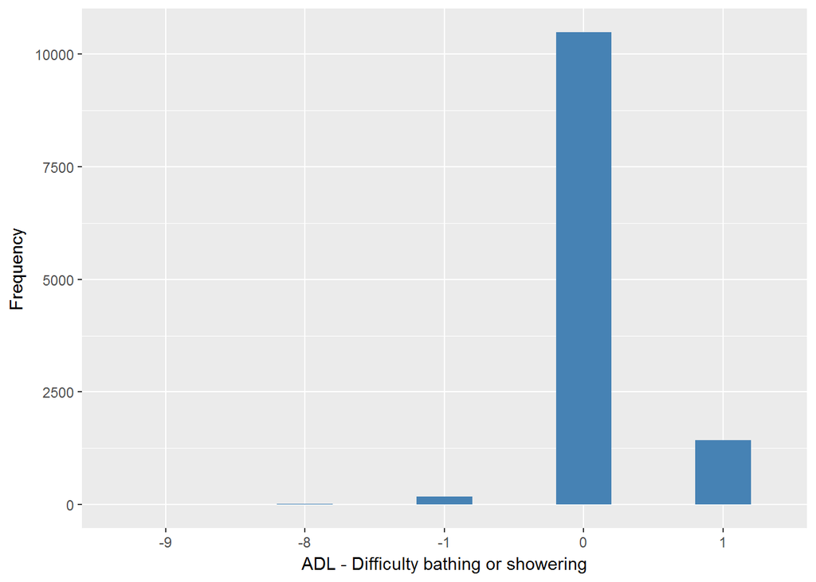

#### 2.1.1.2 Harmonisation algorithm

To compute the harmonize variable from the study-specific variable it has to be recoded as follows:

- `1 into 0`
- `0 into 1`
- `-9 Refusal into 997`
- `-8 Don't know into 998`
- `-1 Not applicable into 996`

**R script:**

```r
ELSA_ds_w1 <- tibble(id = ELSA_w1_adl_bathing$id)
ELSA_ds_w1$adl_bathing <- car::recode(ELSA_w1_adl_bathing$headlba, "0 = '1';1 = '0';-9 = '997';-8 = '998';-1 = '996' ")
ELSA_ds_w1$adl_bathing <- labelled(ELSA_ds_w1$adl_bathing, labels = c(Yes = 0,
    No = 1, Missing = 999, Do_not_know = 998, Refuse = 997, Not_applicable = 996,
    Does_not_answer = 995, Not_attempt_not_done = 994, Disable_to_measure = 993,
    Impute = 992, CAPI_interviewer_error = 991))
```

#### 2.1.1.3 Statistical description of the new harmonised variable

| Sample size | Missing values |
| --- | --- |
| 12099 | 191 |

Category

|  | 0 | 1 |
| --- | --- | --- |
| Frequency | 1423.00 | 10485.00 |
| Percentage | 11.76 | 86.66 |

Type of missing

|  | 991 | 992 | 993 | 994 | 995 | 996 | 997 | 998 | 999 | NA |
| --- | --- | --- | --- | --- | --- | --- | --- | --- | --- | --- |
| Frequency | 0 | 0 | 0 | 0 | 0 | 175.00 | 4.00 | 12.0 | 0 | 0 |
| Percentage | 0 | 0 | 0 | 0 | 0 | 1.45 | 0.03 | 0.1 | 0 | 0 |

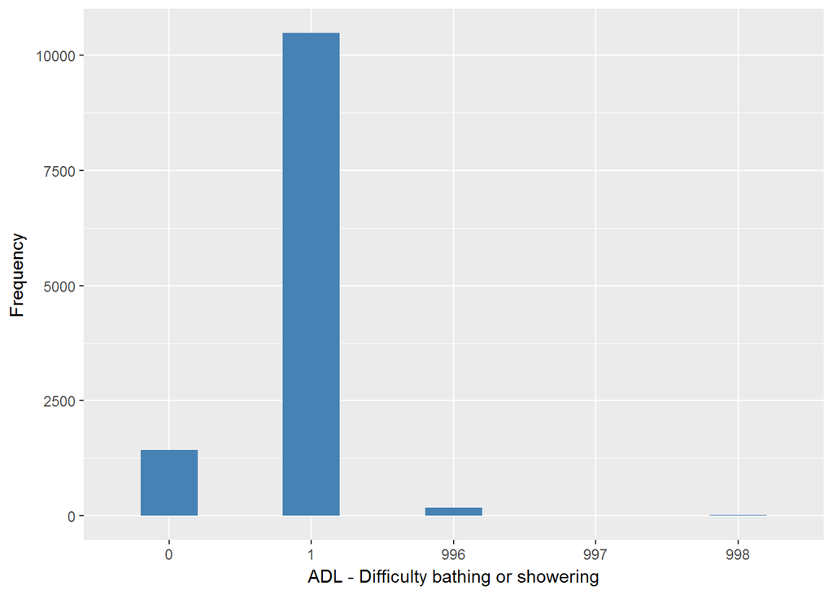

#### 2.1.1.4 Validation

|  | 1->0 | 0->1 | -1->996 | -9->997 | -8->998 |
| --- | --- | --- | --- | --- | --- |
| BeforeH | 1423 | 10485 | 175 | 4 | 12 |
| AfterH | 1423 | 10485 | 175 | 4 | 12 |

### 2.1.2 Wave 2

#### 2.1.2.1 Study-specific variable description

- Name: `headlba`
- Label: `ADL: difficulty bathing or showering`
- Categories:
  - `0 = Not mentioned`
  - `1 = Mentioned`
- Missings
  - `-9 = Refusal`
  - `-8 = Don't know`
- Description:

| Sample size | Missing values |
| --- | --- |
| 9432 | 0 |

Category

|  | -9 | -8 | 0 | 1 |
| --- | --- | --- | --- | --- |
| Frequency | 2.00 | 1.00 | 8298.00 | 1131.00 |
| Percentage | 0.02 | 0.01 | 87.98 | 11.99 |

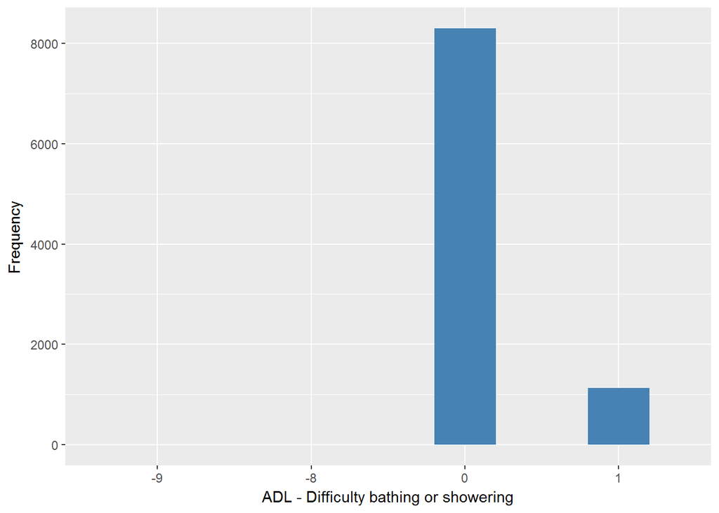

#### 2.1.2.2 Harmonisation algorithm

To compute the harmonize variable from the study-specific variable it has to be recoded as follows:

- `1 into 0`
- `0 into 1`
- `-9 Refusal into 997`
- `-8 Don't know into 998`

**R script:**

```r
ELSA_ds_w2 <- tibble(id = ELSA_w2_adl_bathing$id)
ELSA_ds_w2$adl_bathing <- car::recode(ELSA_w2_adl_bathing$headlba, "0 = '1';1 = '0';-9 = '997';-8 = '998';-1 = '996' ")
ELSA_ds_w2$adl_bathing <- labelled(ELSA_ds_w2$adl_bathing, labels = c(Yes = 0,
    No = 1, Missing = 999, Do_not_know = 998, Refuse = 997, Not_applicable = 996,
    Does_not_answer = 995, Not_attempt_not_done = 994, Disable_to_measure = 993,
    Impute = 992, CAPI_interviewer_error = 991))
```

#### 2.1.2.3 Statistical description of the new harmonised variable

| Sample size | Missing values |
| --- | --- |
| 9432 | 3 |

Category

|  | 0 | 1 |
| --- | --- | --- |
| Frequency | 1131.00 | 8298.00 |
| Percentage | 11.99 | 87.98 |

Type of missing

|  | 991 | 992 | 993 | 994 | 995 | 996 | 997 | 998 | 999 | NA |
| --- | --- | --- | --- | --- | --- | --- | --- | --- | --- | --- |
| Frequency | 0 | 0 | 0 | 0 | 0 | 0 | 2.00 | 1.00 | 0 | 0 |
| Percentage | 0 | 0 | 0 | 0 | 0 | 0 | 0.02 | 0.01 | 0 | 0 |

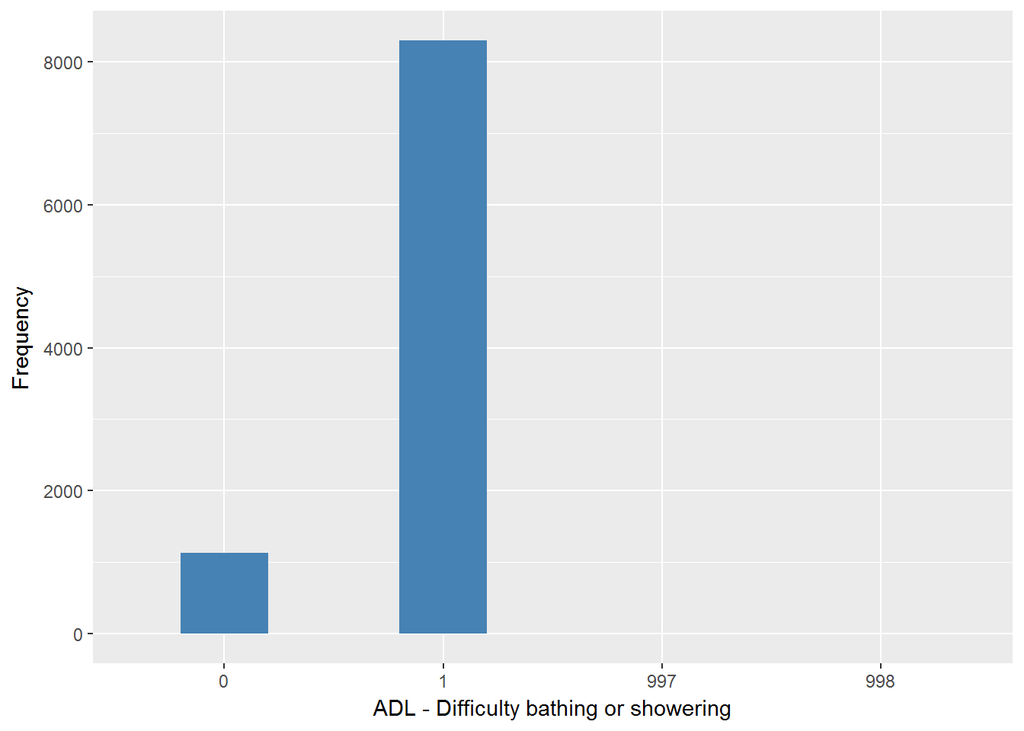

#### 2.1.2.4 Validation

|  | 1->0 | 0->1 | -9->997 | -8->998 |
| --- | --- | --- | --- | --- |
| BeforeH | 1131 | 8298 | 2 | 1 |
| AfterH | 1131 | 8298 | 2 | 1 |

### 2.1.3 Wave 3

#### 2.1.3.1 Study-specific variable description

- Name: `headlba`
- Label: `ADL: difficulty bathing or showering`
- Categories:
  - `0 = Not mentioned`
  - `1 = Mentioned`
- Missings
  - `-1 = Not applicable`
- Description:

HEADLBA

| Sample size | Missing values |
| --- | --- |
| 9771 | 0 |

Category

|  | -1 | 0 | 1 |
| --- | --- | --- | --- |
| Frequency | 4.00 | 8691.00 | 1076.00 |
| Percentage | 0.04 | 88.95 | 11.01 |

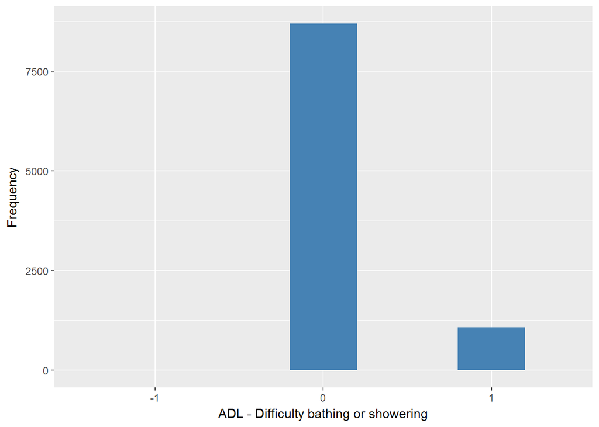

#### 2.1.3.2 Harmonisation algorithm

To compute the harmonize variable from the study-specific variable it has to be recoded as follows:

- `1 into 0`
- `0 into 1`
- `-1 Not applicable into 996`

**R script:**

```r
ELSA_ds_w3 <- tibble(id = ELSA_w3_adl_bathing$id)
ELSA_ds_w3$adl_bathing <- car::recode(ELSA_w3_adl_bathing$headlba, "0 = '1';1 = '0';-9 = '997';-8 = '998';-1 = '996' ")
ELSA_ds_w3$adl_bathing <- labelled(ELSA_ds_w3$adl_bathing, labels = c(Yes = 0,
    No = 1, Missing = 999, Do_not_know = 998, Refuse = 997, Not_applicable = 996,
    Does_not_answer = 995, Not_attempt_not_done = 994, Disable_to_measure = 993,
    Impute = 992, CAPI_interviewer_error = 991))
```

#### 2.1.3.3 Statistical description of the new harmonised variable

| Sample size | Missing values |
| --- | --- |
| 9771 | 4 |

Category

|  | 0 | 1 |
| --- | --- | --- |
| Frequency | 1076.00 | 8691.00 |
| Percentage | 11.01 | 88.95 |

Type of missing

|  | 991 | 992 | 993 | 994 | 995 | 996 | 997 | 998 | 999 | NA |
| --- | --- | --- | --- | --- | --- | --- | --- | --- | --- | --- |
| Frequency | 0 | 0 | 0 | 0 | 0 | 4.00 | 0 | 0 | 0 | 0 |
| Percentage | 0 | 0 | 0 | 0 | 0 | 0.04 | 0 | 0 | 0 | 0 |

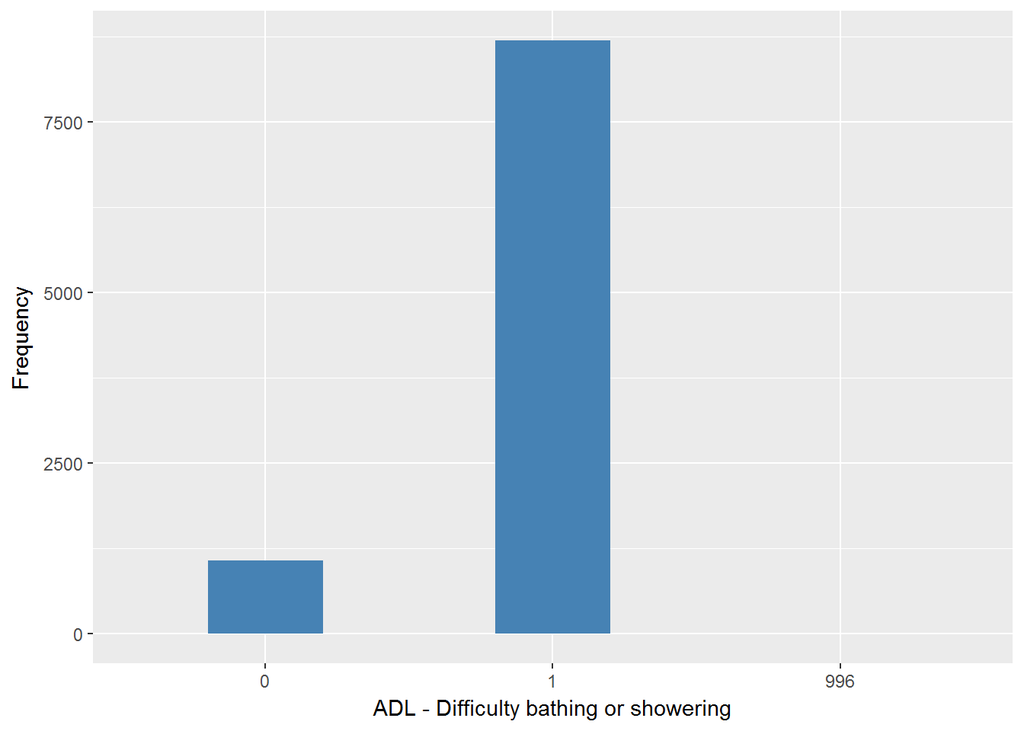

#### 2.1.3.4 Validation

|  | 1->0 | 0->1 | -1->996 |
| --- | --- | --- | --- |
| BeforeH | 1076 | 8691 | 4 |
| AfterH | 1076 | 8691 | 4 |

### 2.1.4 Wave 4

#### 2.1.4.1 Study-specific variable description

- Name: `headlba`
- Label: `ADL: difficulty bathing or showering`
- Categories:
  - `0 = Not mentioned`
  - `1 = Mentioned`
- Missings
  - `-9 = Refusal`
  - `-8 = Don't know`
- Description:

| Sample size | Missing values |
| --- | --- |
| 11050 | 0 |

Category

|  | -9 | -8 | 0 | 1 |
| --- | --- | --- | --- | --- |
| Frequency | 7.00 | 2.00 | 9941.00 | 1100.00 |
| Percentage | 0.06 | 0.02 | 89.96 | 9.95 |

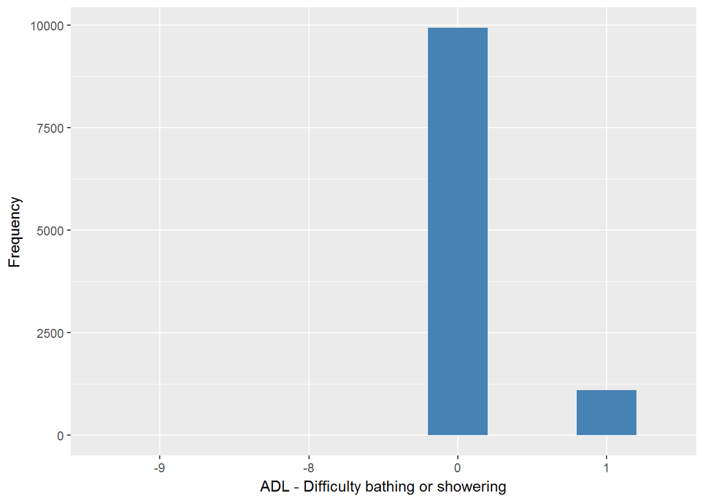

#### 2.1.4.2 Harmonisation algorithm

To compute the harmonize variable from the study-specific variable it has to be recoded as follows:

- `1 into 0`
- `0 into 1`
- `-9 Refusal into 997`
- `-8 Don't know into 998`

**R script:**

```r
ELSA_ds_w4 <- tibble(id = ELSA_w4_adl_bathing$id)
ELSA_ds_w4$adl_bathing <- car::recode(ELSA_w4_adl_bathing$headlba, "0 = '1';1 = '0';-9 = '997';-8 = '998';-1 = '996' ")
ELSA_ds_w4$adl_bathing <- labelled(ELSA_ds_w4$adl_bathing, labels = c(Yes = 0,
    No = 1, Missing = 999, Do_not_know = 998, Refuse = 997, Not_applicable = 996,
    Does_not_answer = 995, Not_attempt_not_done = 994, Disable_to_measure = 993,
    Impute = 992, CAPI_interviewer_error = 991))
```

#### 2.1.4.3 Statistical description of the new harmonised variable

| Sample size | Missing values |
| --- | --- |
| 11050 | 9 |

Category

|  | 0 | 1 |
| --- | --- | --- |
| Frequency | 1100.00 | 9941.00 |
| Percentage | 9.95 | 89.96 |

Type of missing

|  | 991 | 992 | 993 | 994 | 995 | 996 | 997 | 998 | 999 | NA |
| --- | --- | --- | --- | --- | --- | --- | --- | --- | --- | --- |
| Frequency | 0 | 0 | 0 | 0 | 0 | 0 | 7.00 | 2.00 | 0 | 0 |
| Percentage | 0 | 0 | 0 | 0 | 0 | 0 | 0.06 | 0.02 | 0 | 0 |

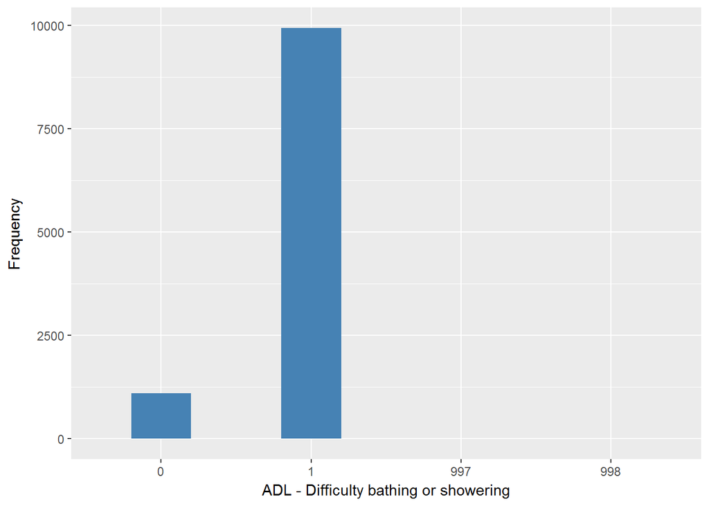

#### 2.1.4.4 Validation

|  | 1->0 | 0->1 | -9->997 | -8->998 |
| --- | --- | --- | --- | --- |
| BeforeH | 1100 | 9941 | 7 | 2 |
| AfterH | 1100 | 9941 | 7 | 2 |

### 2.1.5 Wave 5

#### 2.1.5.1 Study-specific variable description

- Name: `headlba`
- Label: `ADL: difficulty bathing or showering`
- Categories:
  - `0 = Not mentioned`
  - `1 = Mentioned`
- Missings
  - `-9 = Refusal`
  - `-8 = Don't know`
- Description:

| Sample size | Missing values |
| --- | --- |
| 10274 | 0 |

Category

|  | -9 | -8 | 0 | 1 |
| --- | --- | --- | --- | --- |
| Frequency | 5.00 | 3.00 | 9249.00 | 1017.0 |
| Percentage | 0.05 | 0.03 | 90.02 | 9.9 |

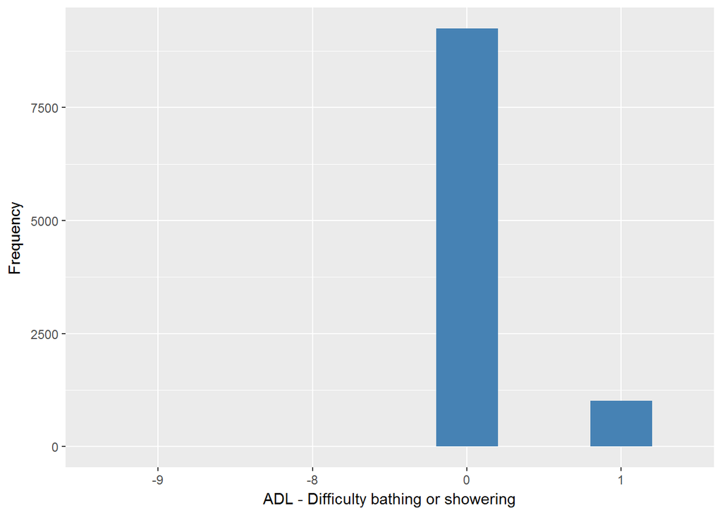

#### 2.1.5.2 Harmonisation algorithm

To compute the harmonize variable from the study-specific variable it has to be recoded as follows:

- `1 into 0`
- `0 into 1`
- `-9 Refusal into 997`
- `-8 Don't know into 998`

**R script:**

```r
ELSA_ds_w5 <- tibble(id = ELSA_w5_adl_bathing$id)
ELSA_ds_w5$adl_bathing <- car::recode(ELSA_w5_adl_bathing$headlba, "0 = '1';1 = '0';-9 = '997';-8 = '998';-1 = '996' ")
ELSA_ds_w5$adl_bathing <- labelled(ELSA_ds_w5$adl_bathing, labels = c(Yes = 0,
    No = 1, Missing = 999, Do_not_know = 998, Refuse = 997, Not_applicable = 996,
    Does_not_answer = 995, Not_attempt_not_done = 994, Disable_to_measure = 993,
    Impute = 992, CAPI_interviewer_error = 991))
```

#### 2.1.5.3 Statistical description of the new harmonised variable

| Sample size | Missing values |
| --- | --- |
| 10274 | 8 |

Category

|  | 0 | 1 |
| --- | --- | --- |
| Frequency | 1017.0 | 9249.00 |
| Percentage | 9.9 | 90.02 |

Type of missing

|  | 991 | 992 | 993 | 994 | 995 | 996 | 997 | 998 | 999 | NA |
| --- | --- | --- | --- | --- | --- | --- | --- | --- | --- | --- |
| Frequency | 0 | 0 | 0 | 0 | 0 | 0 | 5.00 | 3.00 | 0 | 0 |
| Percentage | 0 | 0 | 0 | 0 | 0 | 0 | 0.05 | 0.03 | 0 | 0 |

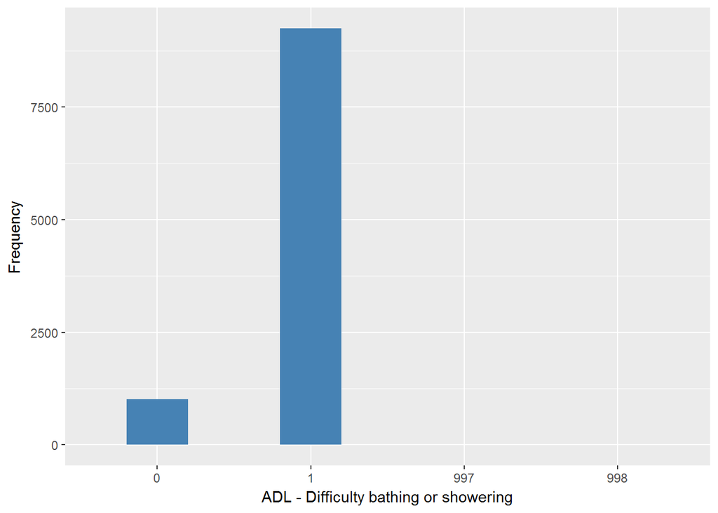

#### 2.1.5.4 Validation

|  | 1->0 | 0->1 | -9->997 | -8->998 |
| --- | --- | --- | --- | --- |
| BeforeH | 1017 | 9249 | 5 | 3 |
| AfterH | 1017 | 9249 | 5 | 3 |

### 2.1.6 Wave 6

#### 2.1.6.1 Study-specific variable description

- Name: `headlba`
- Label: `ADL: difficulty bathing or showering`
- Categories:
  - `0 = Not mentioned`
  - `1 = Mentioned`
- Missings
  - `-9 = Refusal`
  - `-8 = Don't know`
- Description:

HEADLBA

| Sample size | Missing values |
| --- | --- |
| 10601 | 0 |

Category

|  | -9 | -8 | 0 | 1 |
| --- | --- | --- | --- | --- |
| Frequency | 3.00 | 2.00 | 9586.00 | 1010.00 |
| Percentage | 0.03 | 0.02 | 90.43 | 9.53 |

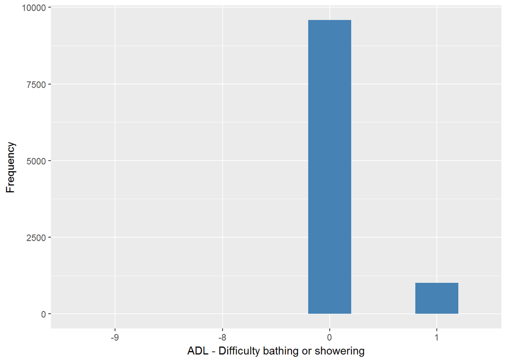

#### 2.1.6.2 Harmonisation algorithm

To compute the harmonize variable from the study-specific variable it has to be recoded as follows:

- `1 into 0`
- `0 into 1`
- `-9 Refusal into 997`
- `-8 Don't know into 998`

**R script:**

```r
ELSA_ds_w6 <- tibble(id = ELSA_w6_adl_bathing$id)
ELSA_ds_w6$adl_bathing <- car::recode(ELSA_w6_adl_bathing$headlba, "0 = '1';1 = '0';-9 = '997';-8 = '998';-1 = '996' ")
ELSA_ds_w6$adl_bathing <- labelled(ELSA_ds_w6$adl_bathing, labels = c(Yes = 0,
    No = 1, Missing = 999, Do_not_know = 998, Refuse = 997, Not_applicable = 996,
    Does_not_answer = 995, Not_attempt_not_done = 994, Disable_to_measure = 993,
    Impute = 992, CAPI_interviewer_error = 991))
```

#### 2.1.6.3 Statistical description of the new harmonised variable

| Sample size | Missing values |
| --- | --- |
| 10601 | 5 |

Category

|  | 0 | 1 |
| --- | --- | --- |
| Frequency | 1010.00 | 9586.00 |
| Percentage | 9.53 | 90.43 |

Type of missing

|  | 991 | 992 | 993 | 994 | 995 | 996 | 997 | 998 | 999 | NA |
| --- | --- | --- | --- | --- | --- | --- | --- | --- | --- | --- |
| Frequency | 0 | 0 | 0 | 0 | 0 | 0 | 3.00 | 2.00 | 0 | 0 |
| Percentage | 0 | 0 | 0 | 0 | 0 | 0 | 0.03 | 0.02 | 0 | 0 |

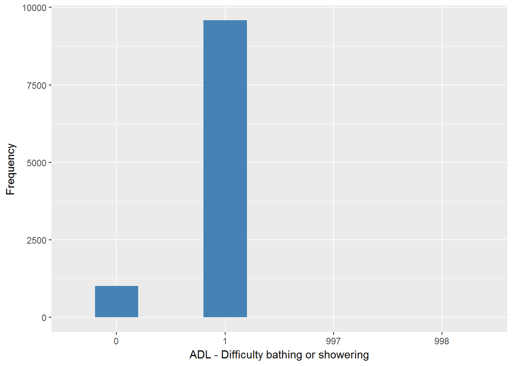

#### 2.1.6.4 Validation

|  | 1->0 | 0->1 | -9->997 | -8->998 |
| --- | --- | --- | --- | --- |
| BeforeH | 1010 | 9586 | 3 | 2 |
| AfterH | 1010 | 9586 | 3 | 2 |

### 2.1.7 Wave 7

#### 2.1.7.1 Study-specific variable description

| Sample size | Missing values |
| --- | --- |
| 9666 | 0 |

Category

|  | -8 | 0 | 1 |
| --- | --- | --- | --- |
| Frequency | 2.00 | 8778.00 | 886.00 |
| Percentage | 0.02 | 90.81 | 9.17 |

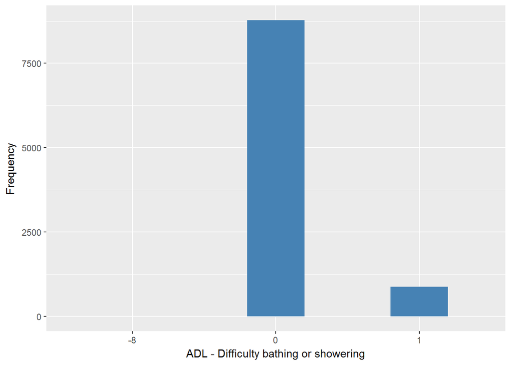

#### 2.1.7.2 Harmonisation algorithm

To compute the harmonize variable from the study-specific variable it has to be recoded as follows:

- `1 into 0`
- `0 into 1`
- `-8 Don't know into 998`

**R script:**

```r
ELSA_ds_w7 <- tibble(id = ELSA_w7_adl_bathing$id)
ELSA_ds_w7$adl_bathing <- car::recode(ELSA_w7_adl_bathing$headlba, "0 = '1';1 = '0';-9 = '997';-8 = '998';-1 = '996' ")
ELSA_ds_w7$adl_bathing <- labelled(ELSA_ds_w7$adl_bathing, labels = c(Yes = 0,
    No = 1, Missing = 999, Do_not_know = 998, Refuse = 997, Not_applicable = 996,
    Does_not_answer = 995, Not_attempt_not_done = 994, Disable_to_measure = 993,
    Impute = 992, CAPI_interviewer_error = 991))
```

#### 2.1.7.3 Statistical description of the new harmonised variable

| Sample size | Missing values |
| --- | --- |
| 9666 | 2 |

Category

|  | 0 | 1 |
| --- | --- | --- |
| Frequency | 886.00 | 8778.00 |
| Percentage | 9.17 | 90.81 |

Type of missing

|  | 991 | 992 | 993 | 994 | 995 | 996 | 997 | 998 | 999 | NA |
| --- | --- | --- | --- | --- | --- | --- | --- | --- | --- | --- |
| Frequency | 0 | 0 | 0 | 0 | 0 | 0 | 0 | 2.00 | 0 | 0 |
| Percentage | 0 | 0 | 0 | 0 | 0 | 0 | 0 | 0.02 | 0 | 0 |

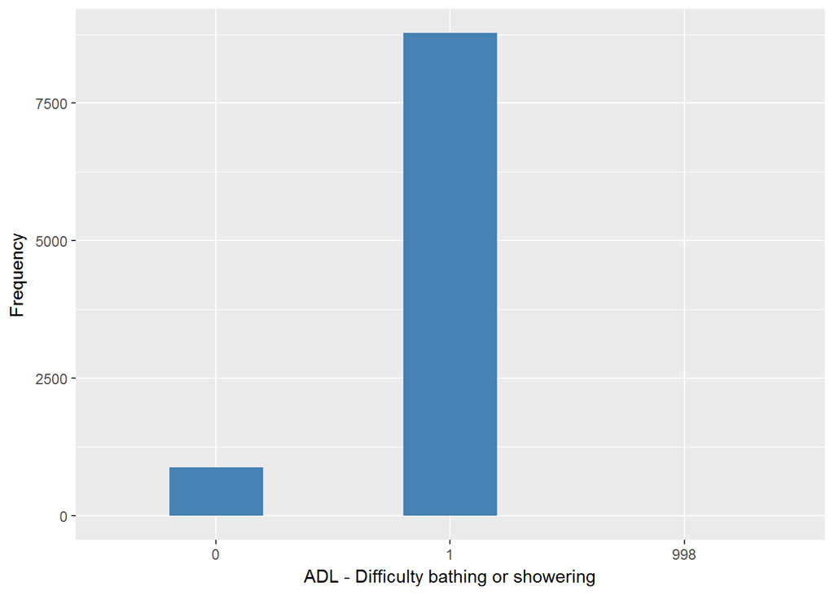

#### 2.1.7.4 Validation

|  | 1->0 | 0->1 | -8->998 |
| --- | --- | --- | --- |
| BeforeH | 886 | 8778 | 2 |
| AfterH | 886 | 8778 | 2 |

# 3 Quality control

No comments.

### 3.0.1 Summary of descriptive statistics of the harmonised variable accross populations and waves

Two tables are generated:

1. Percentages of categories in each harmonised variable.
2. Frequencies and percentages of individuals with different trajectories. To avoid too large table, Only trajectories with percentages larger than 0.3 are shown.

| val | label | w1 | w2 | w3 | w4 | w5 | w6 | w7 |
| --- | --- | --- | --- | --- | --- | --- | --- | --- |
| 0 | Presence | 11.76 | 11.99 | 11.01 | 9.95 | 9.9 | 9.53 | 9.17 |
| 1 | Absence | 86.66 | 87.98 | 88.95 | 89.96 | 90.02 | 90.43 | 90.81 |
| 991 | CAPI_interviewer_error | 0 | 0 | 0 | 0 | 0 | 0 | 0 |
| 992 | Impute | 0 | 0 | 0 | 0 | 0 | 0 | 0 |
| 993 | Disable_to_measure | 0 | 0 | 0 | 0 | 0 | 0 | 0 |
| 994 | Not_attempt_not_done | 0 | 0 | 0 | 0 | 0 | 0 | 0 |
| 995 | Does_not_answer | 0 | 0 | 0 | 0 | 0 | 0 | 0 |
| 996 | Not_applicable | 1.45 | 0 | 0.04 | 0 | 0 | 0 | 0 |
| 997 | Refuse | 0.03 | 0.02 | 0 | 0.06 | 0.05 | 0.03 | 0 |
| 998 | Do_not_know | 0.1 | 0.01 | 0 | 0.02 | 0.03 | 0.02 | 0.02 |
| 999 | Missing | 0 | 0 | 0 | 0 | 0 | 0 | 0 |
| NA | NA | 0 | 0 | 0 | 0 | 0 | 0 | 0 |
| n | sample size | 12099 | 9432 | 9771 | 11050 | 10274 | 10601 | 9666 |

|  | val | frq | raw.prc |
| --- | --- | --- | --- |
| 45 | 000NANANANA | 78 | 0.42 |
| 94 | 00NANANANANA | 124 | 0.67 |
| 168 | 01NANANANANA | 66 | 0.36 |
| 215 | 0NANANANANANA | 376 | 2.03 |
| 306 | 10NANANANANA | 99 | 0.54 |
| 353 | 110NANANANA | 63 | 0.34 |
| 383 | 1111101 | 59 | 0.32 |
| 385 | 1111110 | 120 | 0.65 |
| 386 | 1111111 | 3370 | 18.23 |
| 387 | 111111NA | 407 | 2.20 |
| 390 | 11111NANA | 271 | 1.47 |
| 399 | 1111NANANA | 383 | 2.07 |
| 410 | 111NA111 | 92 | 0.50 |
| 421 | 111NANANANA | 626 | 3.39 |
| 441 | 11NA1111 | 87 | 0.47 |
| 465 | 11NANANANANA | 975 | 5.27 |
| 493 | 1NA11111 | 73 | 0.39 |
| 511 | 1NA1NANANANA | 73 | 0.39 |
| 557 | 1NANANANANANA | 1623 | 8.78 |
| 664 | NANA11111 | 774 | 4.19 |
| 665 | NANA1111NA | 104 | 0.56 |
| 668 | NANA111NANA | 76 | 0.41 |
| 675 | NANA11NANANA | 115 | 0.62 |
| 689 | NANA1NANANANA | 286 | 1.55 |
| 724 | NANANA1111 | 1490 | 8.06 |
| 725 | NANANA111NA | 207 | 1.12 |
| 728 | NANANA11NANA | 148 | 0.80 |
| 736 | NANANA1NANANA | 323 | 1.75 |
| 742 | NANANANA111 | 74 | 0.40 |
| 751 | NANANANANA11 | 890 | 4.81 |
| 752 | NANANANANA1NA | 252 | 1.36 |
| 754 | NANANANANANA1 | 486 | 2.63 |
| 755 | NANANANANANANA | 92 | 0.50 |